# Manual Workflow

This notebook shows how to use history matching in **manual mode**, where you control each iteration individually. Manual mode lets you:

- Inspect results before committing to the next iteration
- Change feature selection or emulator type between iterations
- Evaluate emulator diagnostics at each step
- Gain a detailed understanding of what the algorithm is doing

For the fully automated one-call workflow, see Basic Workflow.

```python
import numpy as np
import pandas as pd
import matplotlib.pyplot as plt

import historymatching as hm
import logging; logging.getLogger("historymatching").propagate = False  # keep INFO logs out of the rendered docs
from model import SIR, generate_observed_data

%matplotlib inline
```

import numpy as np import pandas as pd import matplotlib.pyplot as plt import historymatching as hm import logging; logging.getLogger("historymatching").propagate = False # keep INFO logs out of the rendered docs from model import SIR, generate_observed_data %matplotlib inline

[output not shown]

[output not shown]

## Generate Synthetic Observed Data

We define true parameter values and generate synthetic incidence data that we will try to recover through history matching.

```python
beta_true  = 1.3
gamma_true = 0.5
population_size    = 10_000
n_seed_infections  = 100

incidence_obs, true_model = generate_observed_data(
    beta_true=beta_true,
    gamma_true=gamma_true,
    population_size=population_size,
    n_seed_infections=n_seed_infections,
    seed=0,
)

data = incidence_obs.to_frame()  # DataFrame with column 'incidence', index 'day'
data.head()
```

beta_true = 1.3 gamma_true = 0.5 population_size = 10_000 n_seed_infections = 100 incidence_obs, true_model = generate_observed_data( beta_true=beta_true, gamma_true=gamma_true, population_size=population_size, n_seed_infections=n_seed_infections, seed=0, ) data = incidence_obs.to_frame() # DataFrame with column 'incidence', index 'day' data.head()

| day | incidence |
| --- | --- |
| 0 | 0.0 |
| 1 | 177.0 |
| 2 | 415.0 |
| 3 | 762.0 |
| 4 | 1246.0 |

```python
data.plot(style="o")
plt.title("Observed daily incidence")
plt.ylabel("New cases")
plt.xlabel("Day")
plt.grid(linestyle=":")
plt.show()
```

data.plot(style="o") plt.title("Observed daily incidence") plt.ylabel("New cases") plt.xlabel("Day") plt.grid(linestyle=":") plt.show()

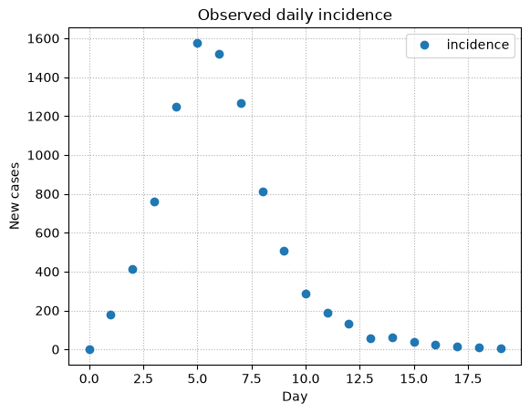

## Define Parameter Space and Observations

```python
parameter_bounds = {
    "beta":  (0.3, 3.0),   # narrower than 01 — avoids extinction / burn-through
    "gamma": (0.1, 1.0),
}

# One observation per day of the incidence time series
observations_dict = {
    f"incidence_{day}": (value, 10.0)
    for day, value in enumerate(data["incidence"])
}

print(f"Parameter space: {parameter_bounds}")
print(f"Observations: {len(observations_dict)} features (one per day)")
```

parameter_bounds = { "beta": (0.3, 3.0), # narrower than 01 — avoids extinction / burn-through "gamma": (0.1, 1.0), } # One observation per day of the incidence time series observations_dict = { f"incidence_{day}": (value, 10.0) for day, value in enumerate(data["incidence"]) } print(f"Parameter space: {parameter_bounds}") print(f"Observations: {len(observations_dict)} features (one per day)")

```
Parameter space: {'beta': (0.3, 3.0), 'gamma': (0.1, 1.0)}
Observations: 20 features (one per day)
```

## Define Simulation Function

The simulation function must accept a DataFrame of parameter samples and return a DataFrame of outputs. Column names must match the observation keys.

```python
def sir_model_wrapper(points: pd.DataFrame) -> pd.DataFrame:
    """Run SIR for each row and return incidence time series."""
    results = []
    for parameters in points.itertuples():
        model = SIR(
            beta=parameters.beta,
            gamma=parameters.gamma,
            s0=population_size - n_seed_infections,
            i0=n_seed_infections,
        )
        results.append(pd.Series(model.get_incidence()))
    return pd.concat(results, axis=1).T.add_prefix("incidence_").reset_index(drop=True)
```

def sir_model_wrapper(points: pd.DataFrame) -> pd.DataFrame: """Run SIR for each row and return incidence time series.""" results = [] for parameters in points.itertuples(): model = SIR( beta=parameters.beta, gamma=parameters.gamma, s0=population_size - n_seed_infections, i0=n_seed_infections, ) results.append(pd.Series(model.get_incidence())) return pd.concat(results, axis=1).T.add_prefix("incidence_").reset_index(drop=True)

```python
# Test with a few random points to confirm the wrapper works
np.random.seed(42)
test_points = pd.DataFrame({
    "beta":  np.random.uniform(0.1, 5.0, 5),
    "gamma": np.random.uniform(0.1, 1.0, 5),
})
test_results = sir_model_wrapper(test_points)
print(f"Output shape: {test_results.shape}  (5 runs x {test_results.shape[1]} days)")
```

# Test with a few random points to confirm the wrapper works np.random.seed(42) test_points = pd.DataFrame({ "beta": np.random.uniform(0.1, 5.0, 5), "gamma": np.random.uniform(0.1, 1.0, 5), }) test_results = sir_model_wrapper(test_points) print(f"Output shape: {test_results.shape} (5 runs x {test_results.shape[1]} days)")

```
Output shape: (5, 20)  (5 runs x 20 days)
```

## Configure the History Matching Engine

We use the builder to configure the engine with a manually chosen feature for the first iteration. Feature selection can be updated before each subsequent iteration.

```python
engine = hm.HistoryMatching(
    bounds=parameter_bounds,
    observations=observations_dict,
    function=sir_model_wrapper,
    sampling_strategy="lhs",
    emulator_type="bayes_linear",
    n_samples=500,
    max_iterations=3,
    implausibility_threshold=3.0,
    random_seed=42,
)

print(f"Engine ready.")
print(f"  Samples per iteration:   {engine.n_samples}")
```

engine = hm.HistoryMatching( bounds=parameter_bounds, observations=observations_dict, function=sir_model_wrapper, sampling_strategy="lhs", emulator_type="bayes_linear", n_samples=500, max_iterations=3, implausibility_threshold=3.0, random_seed=42, ) print(f"Engine ready.") print(f" Samples per iteration: {engine.n_samples}")

```
Engine ready.
  Samples per iteration:   500
```

## Iteration 1

Run the first iteration, inspect the results, then commit.

```python
engine.feature_selection = ["incidence_11"]

print("Running iteration 1...")
result_1 = engine.step()

print(f"  Samples generated:  {len(result_1.samples)}")
print(f"  NROY fraction:      {result_1.nroy_fraction:.1%}")
print(f"  Outputs emulated:   {result_1.emulated_outputs}")
print(f"  Emulators trained:  {len(result_1.emulators)}")
```

engine.feature_selection = ["incidence_11"] print("Running iteration 1...") result_1 = engine.step() print(f" Samples generated: {len(result_1.samples)}") print(f" NROY fraction: {result_1.nroy_fraction:.1%}") print(f" Outputs emulated: {result_1.emulated_outputs}") print(f" Emulators trained: {len(result_1.emulators)}")

```
Running iteration 1...
```

```
  Samples generated:  500
  NROY fraction:      11.0%
  Outputs emulated:   ['incidence_11']
  Emulators trained:  1
```

### Inspect Emulator Performance

```python
emulator_1 = result_1.get_emulator("incidence_11")
print(f"Emulator type: {type(emulator_1).__name__}")
emulator_1.info()
```

emulator_1 = result_1.get_emulator("incidence_11") print(f"Emulator type: {type(emulator_1).__name__}") emulator_1.info()

```
Emulator type: BayesLinear
... General information:
      Number of parameters =  2
      Number of samples (total) =  500
      Number of training samples =  375
      Number of testing samples =  125

... Emulator configuration:
      Bayes Linear Emulator
      Nugget:        1e-06
      sigma^2:       703132692.794450
      NLL:           -451.9024
      Optimizer:     converged
      theta (correlation lengths):
        beta: 0.2344
        gamma: 1.1591
      beta (regression coefficients):
        intercept: 297.037399
        beta: -285.625738
        gamma: -90.366184

      This emulator has not been tested yet
```

```python
emulator_1.test()
emulator_1.plot_diagnostics()
```

emulator_1.test() emulator_1.plot_diagnostics()

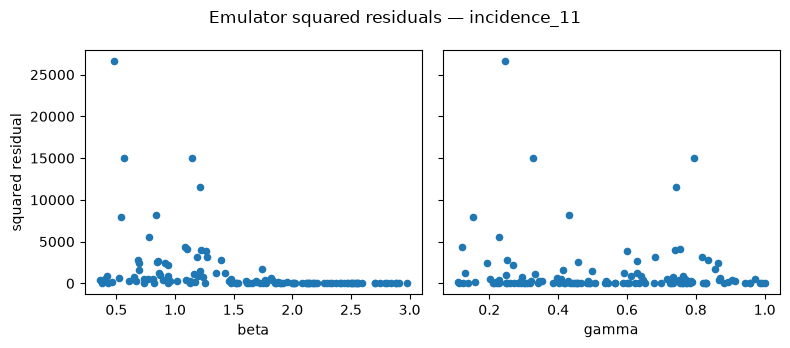

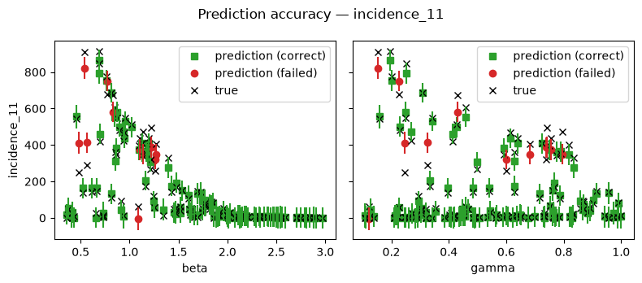

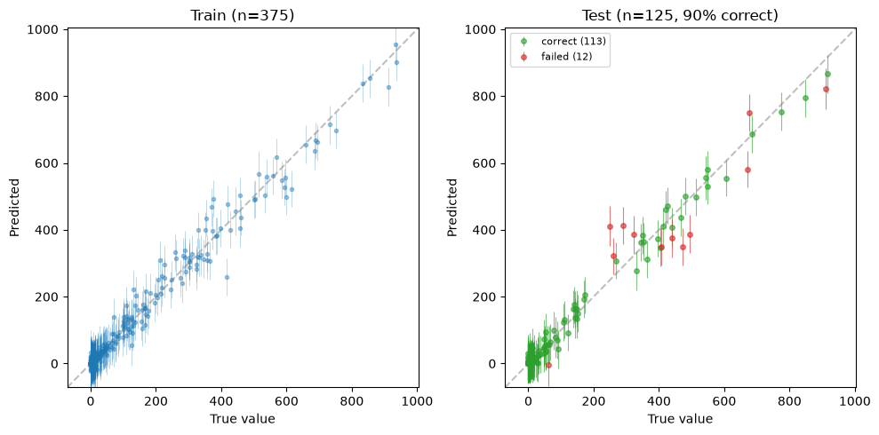

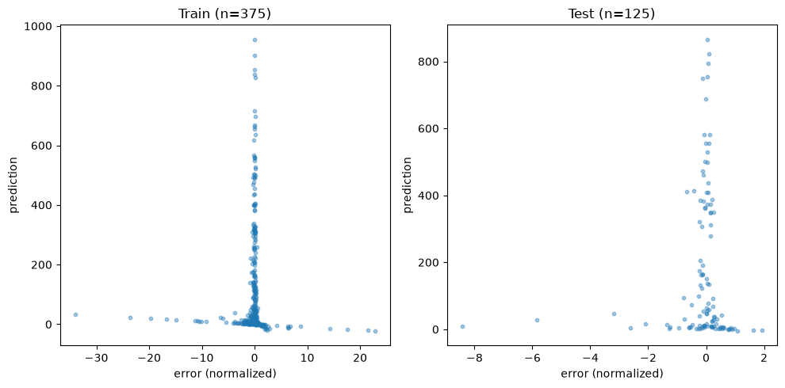

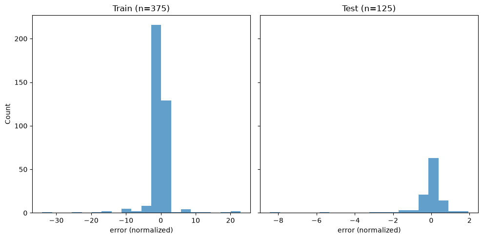

### Inspect Parameter Space After Iteration 1

```python
samples_1 = result_1.samples
pending_2 = engine.get_pending_next_samples()

fig, axes = plt.subplots(1, 2, figsize=(12, 4))

ax = axes[0]
ax.scatter(samples_1["beta"], samples_1["gamma"], alpha=0.6, s=20, color="gray", label="Iteration 1 samples")
ax.scatter(pending_2["beta"],  pending_2["gamma"],  alpha=0.6, s=20, color="green", label="Pending for iteration 2")
ax.axvline(beta_true,  color="red", linestyle="--", linewidth=2, label=f"True beta={beta_true}")
ax.axhline(gamma_true, color="red", linestyle="--", linewidth=2, label=f"True gamma={gamma_true}")
ax.set_xlabel("beta")
ax.set_ylabel("gamma")
ax.set_title("Parameter space after iteration 1")
ax.legend(fontsize=8)
ax.grid(True, alpha=0.3)

ax = axes[1]
sims = sir_model_wrapper(samples_1)
days = np.arange(sims.shape[1])
obs_vals = data["incidence"].values

# Plot each sim as a thin gray line (no legend entries)
for row in sims.values:
    ax.plot(days, row, color="gray", alpha=0.15, linewidth=0.8)
ax.plot(days, obs_vals, "ro-", linewidth=2, markersize=4, label="Observed")

# Highlight the emulated time-point(s) for this wave
emulated_days = [int(f.split("_")[1]) for f in result_1.emulated_outputs]
ax.scatter(emulated_days, obs_vals[emulated_days], s=100, zorder=5,
           facecolors="none", edgecolors="red", linewidths=2, label="Emulated day(s)")

ax.set_xlabel("Day")
ax.set_ylabel("Incidence")
ax.set_title("Simulated trajectories vs observed")
ax.legend(fontsize=8)
ax.grid(linestyle=":")

plt.tight_layout()
plt.show()

print(f"Pending samples for iteration 2: {len(pending_2)}")
print(f"  beta  range: [{pending_2['beta'].min():.3f}, {pending_2['beta'].max():.3f}]")
print(f"  gamma range: [{pending_2['gamma'].min():.3f}, {pending_2['gamma'].max():.3f}]")
```

samples_1 = result_1.samples pending_2 = engine.get_pending_next_samples() fig, axes = plt.subplots(1, 2, figsize=(12, 4)) ax = axes[0] ax.scatter(samples_1["beta"], samples_1["gamma"], alpha=0.6, s=20, color="gray", label="Iteration 1 samples") ax.scatter(pending_2["beta"], pending_2["gamma"], alpha=0.6, s=20, color="green", label="Pending for iteration 2") ax.axvline(beta_true, color="red", linestyle="--", linewidth=2, label=f"True beta={beta_true}") ax.axhline(gamma_true, color="red", linestyle="--", linewidth=2, label=f"True gamma={gamma_true}") ax.set_xlabel("beta") ax.set_ylabel("gamma") ax.set_title("Parameter space after iteration 1") ax.legend(fontsize=8) ax.grid(True, alpha=0.3) ax = axes[1] sims = sir_model_wrapper(samples_1) days = np.arange(sims.shape[1]) obs_vals = data["incidence"].values # Plot each sim as a thin gray line (no legend entries) for row in sims.values: ax.plot(days, row, color="gray", alpha=0.15, linewidth=0.8) ax.plot(days, obs_vals, "ro-", linewidth=2, markersize=4, label="Observed") # Highlight the emulated time-point(s) for this wave emulated_days = [int(f.split("_")[1]) for f in result_1.emulated_outputs] ax.scatter(emulated_days, obs_vals[emulated_days], s=100, zorder=5, facecolors="none", edgecolors="red", linewidths=2, label="Emulated day(s)") ax.set_xlabel("Day") ax.set_ylabel("Incidence") ax.set_title("Simulated trajectories vs observed") ax.legend(fontsize=8) ax.grid(linestyle=":") plt.tight_layout() plt.show() print(f"Pending samples for iteration 2: {len(pending_2)}") print(f" beta range: [{pending_2['beta'].min():.3f}, {pending_2['beta'].max():.3f}]") print(f" gamma range: [{pending_2['gamma'].min():.3f}, {pending_2['gamma'].max():.3f}]")

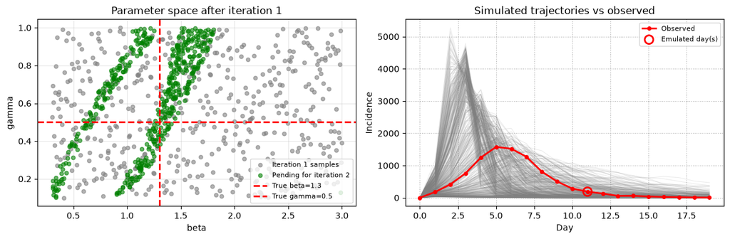

[output not shown]

```python
# Accept the first iteration
engine.commit_step()
print(f"Iteration 1 committed. Current iteration: {engine.current_iteration}")
```

# Accept the first iteration engine.commit_step() print(f"Iteration 1 committed. Current iteration: {engine.current_iteration}")

```
Iteration 1 committed. Current iteration: 1
```

## Iteration 2

Switch to an earlier time point — day 3 is on the rising limb of the epidemic, so it should constrain different parameter combinations than day 11 (descending limb).

```python
engine.feature_selection = ["incidence_3"]
print("Feature selection updated to ['incidence_3']")

print("Running iteration 2...")
result_2 = engine.step()

print(f"  Samples generated:  {len(result_2.samples)}")
print(f"  NROY fraction:      {result_2.nroy_fraction:.1%}")
print(f"  Acceptance rate:    {engine.acceptance_rate:.3f}")
print(f"  Outputs emulated:   {result_2.emulated_outputs}")
```

engine.feature_selection = ["incidence_3"] print("Feature selection updated to ['incidence_3']") print("Running iteration 2...") result_2 = engine.step() print(f" Samples generated: {len(result_2.samples)}") print(f" NROY fraction: {result_2.nroy_fraction:.1%}") print(f" Acceptance rate: {engine.acceptance_rate:.3f}") print(f" Outputs emulated: {result_2.emulated_outputs}")

```
Feature selection updated to ['incidence_3']
Running iteration 2...
```

```
  Samples generated:  500
  NROY fraction:      6.3%
  Acceptance rate:    0.116
  Outputs emulated:   ['incidence_3']
```

### Emulator Diagnostics for Iteration 2

```python
emulator_2 = result_2.get_emulator("incidence_3")
emulator_2.test()

# Show GPflow model summary — check likelihood.variance for overconfidence
# (near-zero noise variance → CIs collapse → many "failed" predictions)
emulator_2.info()
emulator_2.plot_diagnostics()
```

emulator_2 = result_2.get_emulator("incidence_3") emulator_2.test() # Show GPflow model summary — check likelihood.variance for overconfidence # (near-zero noise variance → CIs collapse → many "failed" predictions) emulator_2.info() emulator_2.plot_diagnostics()

```
... General information:
      Number of parameters =  2
      Number of samples (total) =  500
      Number of training samples =  375
      Number of testing samples =  125

... Emulator configuration:
      Bayes Linear Emulator
      Nugget:        1e-06
      sigma^2:       6345669244.243703
      NLL:           -495.4002
      Optimizer:     converged
      theta (correlation lengths):
        beta: 2.1976
        gamma: 3.1739
      beta (regression coefficients):
        intercept: 40.689749
        beta: 2745.231759
        gamma: -765.334558

... Performance results:
      MSE    = 5662.200173528868
      L-inf  = 234.7335441466605
      L-1    = 54.690816511428544
      R2     = 0.9456857846301575
      AIC    = 1084.19597736278
      BIC    = 1089.8526048373847
```

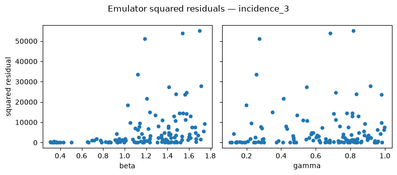

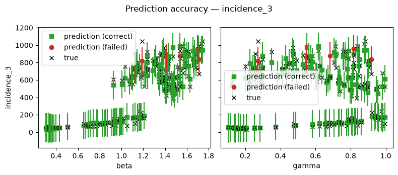

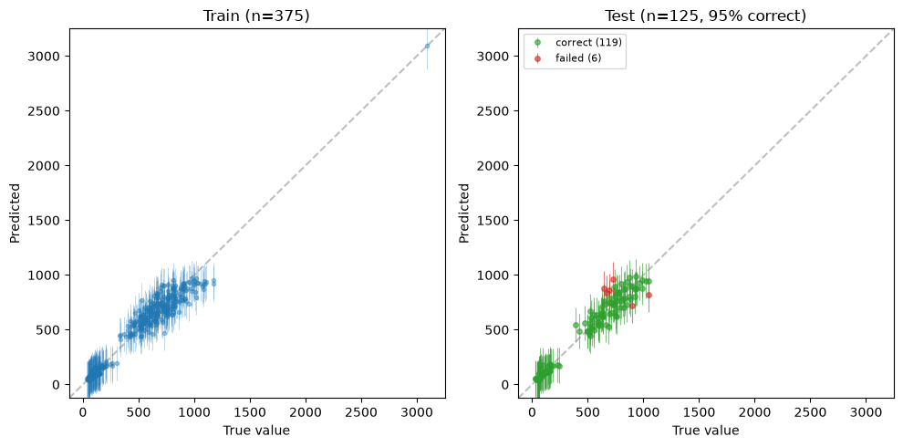

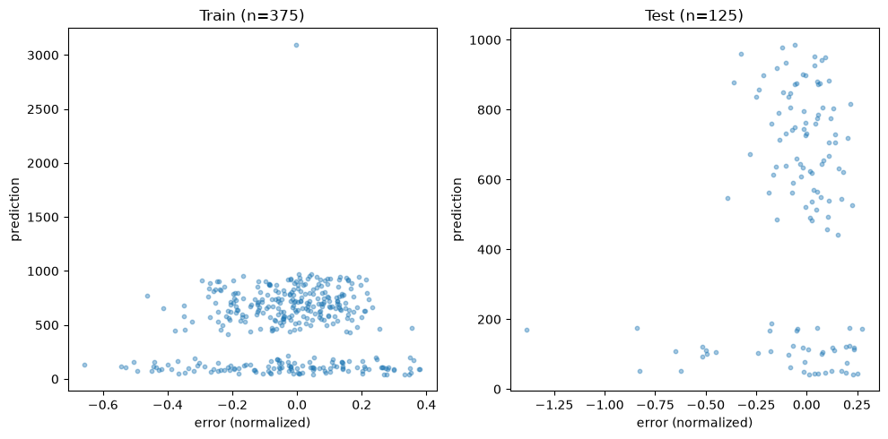

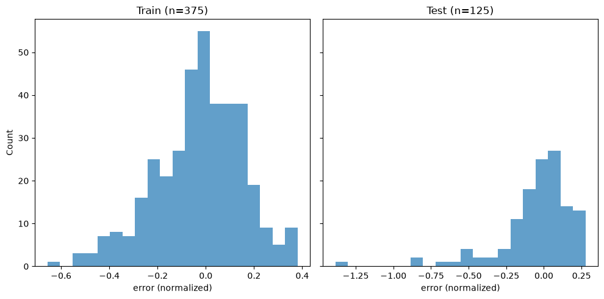

### Parameter Space After Iteration 2

```python
# result_2.samples = training data for iter 2 (passed iter 1 only)
# pending_3 = samples that passed BOTH iter 1 and iter 2 emulators
pending_3 = engine.get_pending_next_samples()

fig, axes = plt.subplots(1, 2, figsize=(12, 4))

ax = axes[0]
ax.scatter(result_2.samples["beta"], result_2.samples["gamma"],
           alpha=0.3, s=15, color="lightgray", label="Iter 2 training (passed iter 1)")
ax.scatter(pending_3["beta"], pending_3["gamma"],
           alpha=0.7, s=20, color="steelblue", label="NROY after iter 2")
ax.axvline(beta_true,  color="red", linestyle="--", linewidth=2, label=f"True beta={beta_true}")
ax.axhline(gamma_true, color="red", linestyle="--", linewidth=2, label=f"True gamma={gamma_true}")
ax.set_xlabel("beta")
ax.set_ylabel("gamma")
ax.set_title("Parameter space after iteration 2")
ax.legend(fontsize=8)
ax.grid(True, alpha=0.3)

ax = axes[1]
sims_nroy = sir_model_wrapper(pending_3)
days = np.arange(sims_nroy.shape[1])
obs_vals = data["incidence"].values

for row in sims_nroy.values:
    ax.plot(days, row, color="steelblue", alpha=0.15, linewidth=0.8)
ax.plot(days, obs_vals, "ro-", linewidth=2, markersize=4, label="Observed")

# Highlight all emulated time-points so far (iterations 1 + 2)
all_emulated = set()
for r in [result_1, result_2]:
    all_emulated.update(int(f.split("_")[1]) for f in r.emulated_outputs)
all_emulated = sorted(all_emulated)
ax.scatter(all_emulated, obs_vals[all_emulated], s=100, zorder=5,
           facecolors="none", edgecolors="red", linewidths=2, label="Emulated day(s)")

ax.set_xlabel("Day")
ax.set_ylabel("Incidence")
ax.set_title("NROY trajectories after 2 iterations")
ax.legend(fontsize=8)
ax.grid(linestyle=":")

plt.tight_layout()
plt.show()

print(f"NROY samples after iteration 2: {len(pending_3)}")
print(f"  beta  range: [{pending_3['beta'].min():.3f}, {pending_3['beta'].max():.3f}]")
print(f"  gamma range: [{pending_3['gamma'].min():.3f}, {pending_3['gamma'].max():.3f}]")

beta_ok  = pending_3["beta"].min()  <= beta_true  <= pending_3["beta"].max()
gamma_ok = pending_3["gamma"].min() <= gamma_true <= pending_3["gamma"].max()
print(f"True beta  in plausible region: {'Yes' if beta_ok  else 'No'}")
print(f"True gamma in plausible region: {'Yes' if gamma_ok else 'No'}")
```

# result_2.samples = training data for iter 2 (passed iter 1 only) # pending_3 = samples that passed BOTH iter 1 and iter 2 emulators pending_3 = engine.get_pending_next_samples() fig, axes = plt.subplots(1, 2, figsize=(12, 4)) ax = axes[0] ax.scatter(result_2.samples["beta"], result_2.samples["gamma"], alpha=0.3, s=15, color="lightgray", label="Iter 2 training (passed iter 1)") ax.scatter(pending_3["beta"], pending_3["gamma"], alpha=0.7, s=20, color="steelblue", label="NROY after iter 2") ax.axvline(beta_true, color="red", linestyle="--", linewidth=2, label=f"True beta={beta_true}") ax.axhline(gamma_true, color="red", linestyle="--", linewidth=2, label=f"True gamma={gamma_true}") ax.set_xlabel("beta") ax.set_ylabel("gamma") ax.set_title("Parameter space after iteration 2") ax.legend(fontsize=8) ax.grid(True, alpha=0.3) ax = axes[1] sims_nroy = sir_model_wrapper(pending_3) days = np.arange(sims_nroy.shape[1]) obs_vals = data["incidence"].values for row in sims_nroy.values: ax.plot(days, row, color="steelblue", alpha=0.15, linewidth=0.8) ax.plot(days, obs_vals, "ro-", linewidth=2, markersize=4, label="Observed") # Highlight all emulated time-points so far (iterations 1 + 2) all_emulated = set() for r in [result_1, result_2]: all_emulated.update(int(f.split("_")[1]) for f in r.emulated_outputs) all_emulated = sorted(all_emulated) ax.scatter(all_emulated, obs_vals[all_emulated], s=100, zorder=5, facecolors="none", edgecolors="red", linewidths=2, label="Emulated day(s)") ax.set_xlabel("Day") ax.set_ylabel("Incidence") ax.set_title("NROY trajectories after 2 iterations") ax.legend(fontsize=8) ax.grid(linestyle=":") plt.tight_layout() plt.show() print(f"NROY samples after iteration 2: {len(pending_3)}") print(f" beta range: [{pending_3['beta'].min():.3f}, {pending_3['beta'].max():.3f}]") print(f" gamma range: [{pending_3['gamma'].min():.3f}, {pending_3['gamma'].max():.3f}]") beta_ok = pending_3["beta"].min() <= beta_true <= pending_3["beta"].max() gamma_ok = pending_3["gamma"].min() <= gamma_true <= pending_3["gamma"].max() print(f"True beta in plausible region: {'Yes' if beta_ok else 'No'}") print(f"True gamma in plausible region: {'Yes' if gamma_ok else 'No'}")

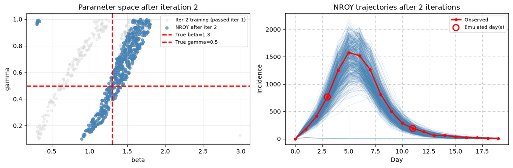

```
NROY samples after iteration 2: 500
  beta  range: [0.302, 1.797]
  gamma range: [0.101, 1.000]
True beta  in plausible region: Yes
True gamma in plausible region: Yes
```

```python
engine.commit_step()
print(f"Iteration 2 committed. Total iterations: {engine.current_iteration}")
```

engine.commit_step() print(f"Iteration 2 committed. Total iterations: {engine.current_iteration}")

```
Iteration 2 committed. Total iterations: 2
```

## Iteration 3: Multiple Emulators Per Wave

A single wave can train **one emulator per output** — the engine loops over the output list and produces a separate emulator for each one. Implausibility is then computed per-emulator and the maximum across all outputs is used to filter samples, so a point must be consistent with *every* constraint to survive.

Assign a list of output names to `engine.feature_selection` to activate this. Here we emulate three time-points simultaneously:

```python
engine.feature_selection = ["incidence_3", "incidence_6", "incidence_11"]

print("Running iteration 3 with 3 simultaneous emulators...")
result_3 = engine.step()

print(f"  Samples generated: {len(result_3.samples)}")
print(f"  NROY fraction:     {result_3.nroy_fraction:.1%}")
print(f"  Outputs emulated:  {result_3.emulated_outputs}")
print(f"  Emulators trained: {len(result_3.emulators)}")

# Save training data for offline debugging
result_3.samples.to_csv("/tmp/wave3_samples.csv", index=False)
result_3.simulation_results.to_csv("/tmp/wave3_sim_results.csv", index=False)
print("\nSaved /tmp/wave3_samples.csv and /tmp/wave3_sim_results.csv")
```

engine.feature_selection = ["incidence_3", "incidence_6", "incidence_11"] print("Running iteration 3 with 3 simultaneous emulators...") result_3 = engine.step() print(f" Samples generated: {len(result_3.samples)}") print(f" NROY fraction: {result_3.nroy_fraction:.1%}") print(f" Outputs emulated: {result_3.emulated_outputs}") print(f" Emulators trained: {len(result_3.emulators)}") # Save training data for offline debugging result_3.samples.to_csv("/tmp/wave3_samples.csv", index=False) result_3.simulation_results.to_csv("/tmp/wave3_sim_results.csv", index=False) print("\nSaved /tmp/wave3_samples.csv and /tmp/wave3_sim_results.csv")

```
Running iteration 3 with 3 simultaneous emulators...
```

```
  Samples generated: 500
  NROY fraction:     3.3%
  Outputs emulated:  ['incidence_3', 'incidence_6', 'incidence_11']
  Emulators trained: 3

Saved /tmp/wave3_samples.csv and /tmp/wave3_sim_results.csv
```

### Inspect each emulator's quality

Iterate over `result.emulators` (a `{feature: emulator}` dict) to check fit quality for every feature before deciding what to keep:

```python
metrics_3 = result_3.get_emulator_quality_metrics()

print(f"{'Output':<20} {'R²':>6}  {'MSE':>10}  {'n_train':>8}")
print("-" * 50)
for feature in result_3.emulated_outputs:
    m   = metrics_3[feature]
    r2  = m.get("r2",      float("nan"))
    mse = m.get("mse",     float("nan"))
    n   = m.get("n_train", "?")
    flag = "  ← poor fit" if r2 < 0.7 else ""
    print(f"{feature:<20} {r2:>6.3f}  {mse:>10.4g}  {n:>8}{flag}")
```

metrics_3 = result_3.get_emulator_quality_metrics() print(f"{'Output':<20} {'R²':>6} {'MSE':>10} {'n_train':>8}") print("-" * 50) for feature in result_3.emulated_outputs: m = metrics_3[feature] r2 = m.get("r2", float("nan")) mse = m.get("mse", float("nan")) n = m.get("n_train", "?") flag = " ← poor fit" if r2 < 0.7 else "" print(f"{feature:<20} {r2:>6.3f} {mse:>10.4g} {n:>8}{flag}")

```
Output                   R²         MSE   n_train
--------------------------------------------------
incidence_3           0.573        7604       375  ← poor fit
incidence_6           0.961        4927       375
incidence_11          0.755       842.9       375
```

```python
for feature in result_3.emulated_outputs:
    r2 = metrics_3[feature].get("r2", float("nan"))
    print(f"\n── {feature} (R²={r2:.3f}) ──")
    em = result_3.get_emulator(feature)
    em.test()
    em.plot_diagnostics()
```

for feature in result_3.emulated_outputs: r2 = metrics_3[feature].get("r2", float("nan")) print(f"\n── {feature} (R²={r2:.3f}) ──") em = result_3.get_emulator(feature) em.test() em.plot_diagnostics()

```
── incidence_3 (R²=0.573) ──
```

```
── incidence_6 (R²=0.961) ──
```

```
── incidence_11 (R²=0.755) ──
```

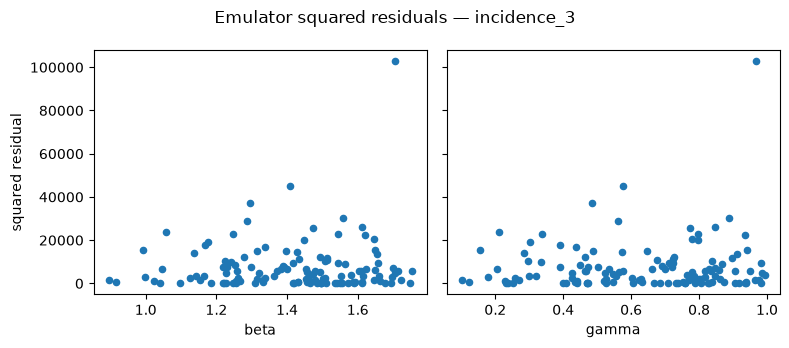

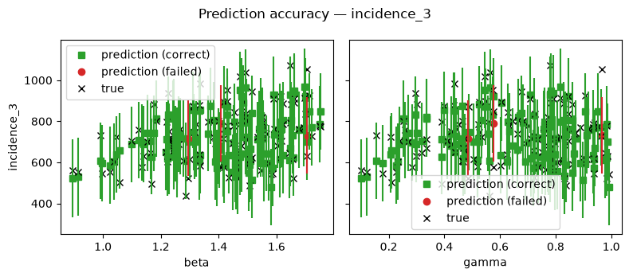

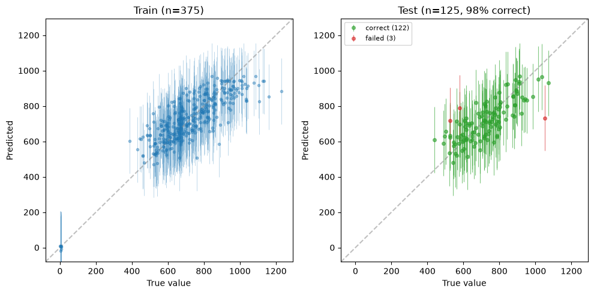

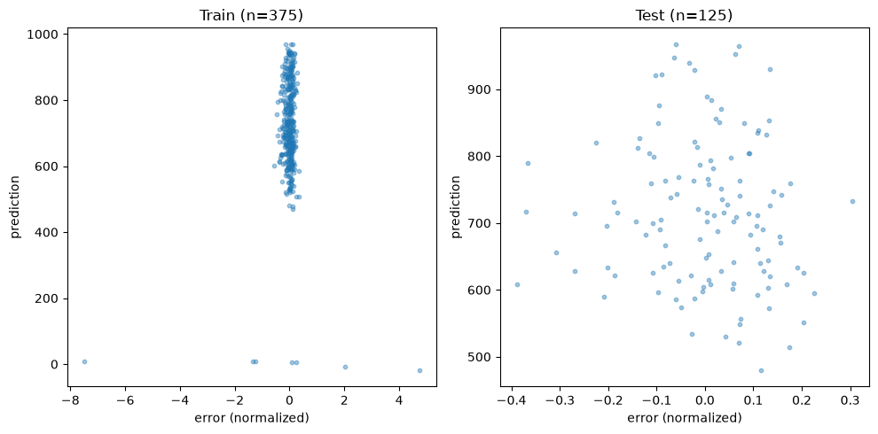

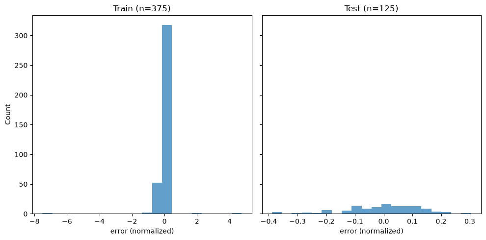

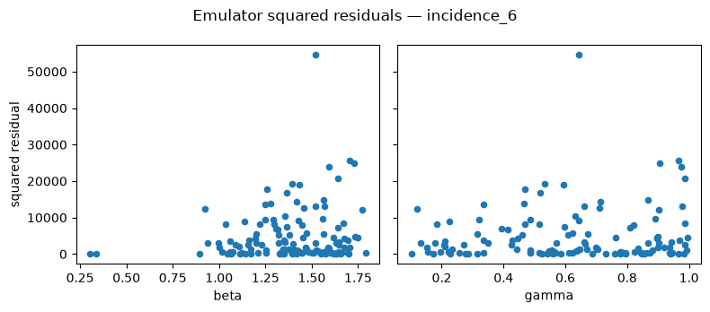

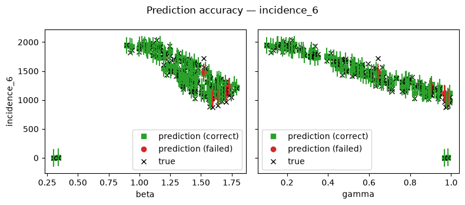

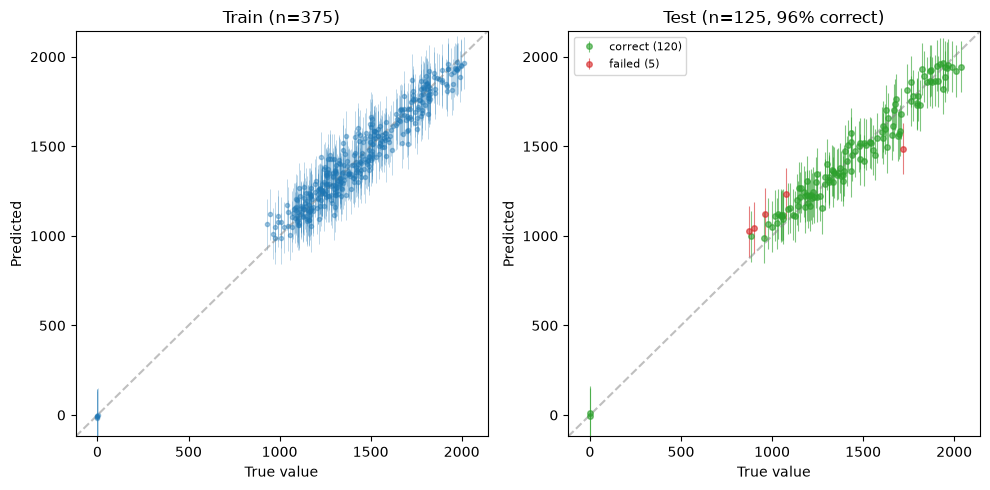

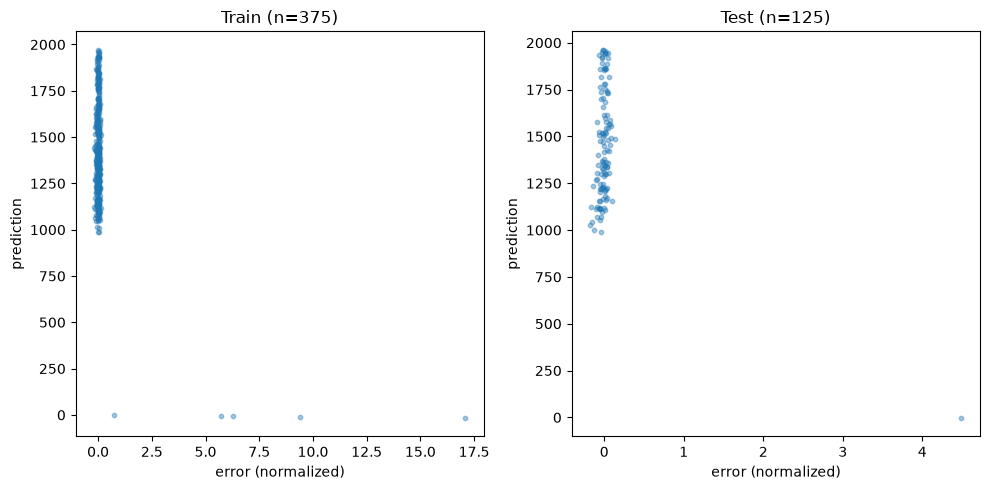

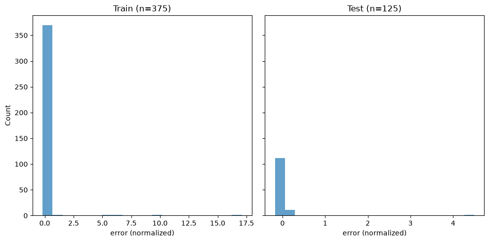

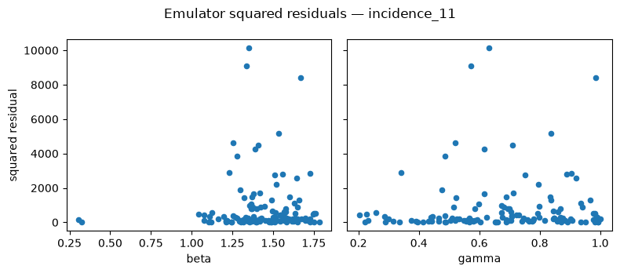

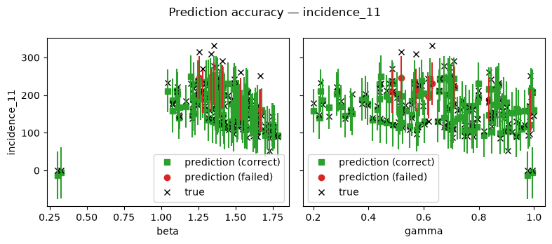

[3 more figures not shown]

### Drop a poor emulator before committing

If one emulator has a low R² it will add noise to the implausibility calculation — potentially excluding valid parameter regions. Call `engine.drop_emulator_from_pending()` to remove it from the pending wave **without discarding the other emulators or re-running any simulations**. The remaining emulators are committed as normal.

> **API note:** `drop_emulator_from_pending()` must be called after `step()` but before `commit_step()`. Calling it after committing raises a `RuntimeError`.

```python
R2_THRESHOLD = 0.7

dropped = []
for feature in result_3.emulated_outputs:
    r2 = metrics_3[feature].get("r2", 1.0)
    if r2 < R2_THRESHOLD:
        engine.drop_emulator_from_pending(feature)
        dropped.append(feature)
        print(f"Dropped '{feature}' (R²={r2:.3f} < {R2_THRESHOLD})")

if not dropped:
    print("All emulators meet the R² threshold — keeping all three.")

# Capture NROY samples BEFORE committing — after commit, pending is cleared
pending_4 = engine.get_pending_next_samples()

engine.commit_step()
print(f"\nIteration 3 committed with {len(result_3.emulated_outputs) - len(dropped)} emulators.")
print(f"Total committed iterations: {engine.current_iteration}")
```

R2_THRESHOLD = 0.7 dropped = [] for feature in result_3.emulated_outputs: r2 = metrics_3[feature].get("r2", 1.0) if r2 < R2_THRESHOLD: engine.drop_emulator_from_pending(feature) dropped.append(feature) print(f"Dropped '{feature}' (R²={r2:.3f} < {R2_THRESHOLD})") if not dropped: print("All emulators meet the R² threshold — keeping all three.") # Capture NROY samples BEFORE committing — after commit, pending is cleared pending_4 = engine.get_pending_next_samples() engine.commit_step() print(f"\nIteration 3 committed with {len(result_3.emulated_outputs) - len(dropped)} emulators.") print(f"Total committed iterations: {engine.current_iteration}")

```
Dropped 'incidence_3' (R²=0.573 < 0.7)
```

```
Iteration 3 committed with 2 emulators.
Total committed iterations: 3
```

### Parameter Space and Trajectories After Iteration 3

```python
# pending_4 = samples that passed ALL 3 waves' emulators (captured before commit)

fig, axes = plt.subplots(1, 2, figsize=(12, 4))

# Left: parameter space — show progression
ax = axes[0]
ax.scatter(result_2.samples["beta"], result_2.samples["gamma"],
           alpha=0.3, s=10, color="lightgray", label="Iter 3 training (passed iters 1+2)")
ax.scatter(pending_4["beta"], pending_4["gamma"],
           alpha=0.7, s=20, color="steelblue", label="NROY after iter 3")
ax.axvline(beta_true,  color="red", linestyle="--", linewidth=2, label=f"True beta={beta_true}")
ax.axhline(gamma_true, color="red", linestyle="--", linewidth=2, label=f"True gamma={gamma_true}")
ax.set_xlabel("beta")
ax.set_ylabel("gamma")
ax.set_title("Parameter space after iteration 3")
ax.legend(fontsize=7)
ax.grid(True, alpha=0.3)

# Right: trajectories from NROY samples
ax = axes[1]
sims_final = sir_model_wrapper(pending_4)
days = np.arange(sims_final.shape[1])
obs_vals = data["incidence"].values

for row in sims_final.values:
    ax.plot(days, row, color="steelblue", alpha=0.15, linewidth=0.8)
ax.plot(days, obs_vals, "ro-", linewidth=2, markersize=4, label="Observed")

# Highlight all emulated time-points across all 3 iterations
all_emulated = set()
for r in [result_1, result_2, result_3]:
    all_emulated.update(int(f.split("_")[1]) for f in r.emulated_outputs)
all_emulated = sorted(all_emulated)
ax.scatter(all_emulated, obs_vals[all_emulated], s=100, zorder=5,
           facecolors="none", edgecolors="red", linewidths=2, label="Emulated day(s)")

ax.set_xlabel("Day")
ax.set_ylabel("Incidence")
ax.set_title("NROY trajectories after 3 iterations")
ax.legend(fontsize=8)
ax.grid(linestyle=":")

plt.tight_layout()
plt.show()

print(f"NROY samples after iteration 3: {len(pending_4)}")
print(f"  beta  range: [{pending_4['beta'].min():.3f}, {pending_4['beta'].max():.3f}]")
print(f"  gamma range: [{pending_4['gamma'].min():.3f}, {pending_4['gamma'].max():.3f}]")
```

# pending_4 = samples that passed ALL 3 waves' emulators (captured before commit) fig, axes = plt.subplots(1, 2, figsize=(12, 4)) # Left: parameter space — show progression ax = axes[0] ax.scatter(result_2.samples["beta"], result_2.samples["gamma"], alpha=0.3, s=10, color="lightgray", label="Iter 3 training (passed iters 1+2)") ax.scatter(pending_4["beta"], pending_4["gamma"], alpha=0.7, s=20, color="steelblue", label="NROY after iter 3") ax.axvline(beta_true, color="red", linestyle="--", linewidth=2, label=f"True beta={beta_true}") ax.axhline(gamma_true, color="red", linestyle="--", linewidth=2, label=f"True gamma={gamma_true}") ax.set_xlabel("beta") ax.set_ylabel("gamma") ax.set_title("Parameter space after iteration 3") ax.legend(fontsize=7) ax.grid(True, alpha=0.3) # Right: trajectories from NROY samples ax = axes[1] sims_final = sir_model_wrapper(pending_4) days = np.arange(sims_final.shape[1]) obs_vals = data["incidence"].values for row in sims_final.values: ax.plot(days, row, color="steelblue", alpha=0.15, linewidth=0.8) ax.plot(days, obs_vals, "ro-", linewidth=2, markersize=4, label="Observed") # Highlight all emulated time-points across all 3 iterations all_emulated = set() for r in [result_1, result_2, result_3]: all_emulated.update(int(f.split("_")[1]) for f in r.emulated_outputs) all_emulated = sorted(all_emulated) ax.scatter(all_emulated, obs_vals[all_emulated], s=100, zorder=5, facecolors="none", edgecolors="red", linewidths=2, label="Emulated day(s)") ax.set_xlabel("Day") ax.set_ylabel("Incidence") ax.set_title("NROY trajectories after 3 iterations") ax.legend(fontsize=8) ax.grid(linestyle=":") plt.tight_layout() plt.show() print(f"NROY samples after iteration 3: {len(pending_4)}") print(f" beta range: [{pending_4['beta'].min():.3f}, {pending_4['beta'].max():.3f}]") print(f" gamma range: [{pending_4['gamma'].min():.3f}, {pending_4['gamma'].max():.3f}]")

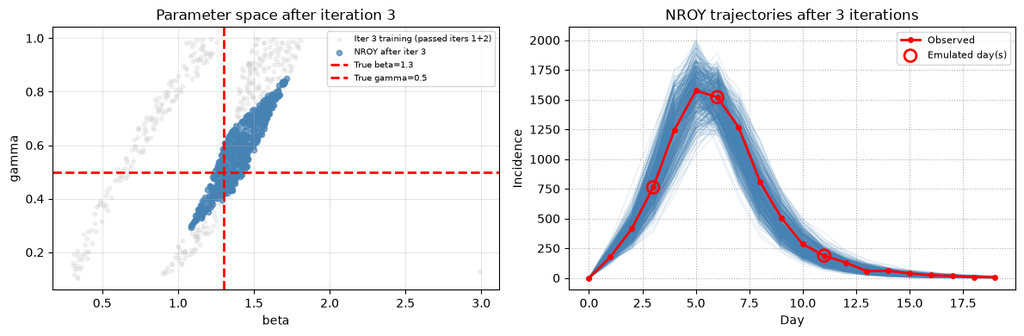

```
NROY samples after iteration 3: 500
  beta  range: [1.084, 1.714]
  gamma range: [0.294, 0.851]
```

## Final Summary

```python
print("FINAL HISTORY MATCHING RESULTS")
print("=" * 50)
print(f"True parameters:  beta={beta_true}, gamma={gamma_true}, R0={beta_true/gamma_true:.2f}")
print()

# pending_4 = NROY after all 3 waves (captured before final commit)
print(f"Plausible ranges after {engine.current_iteration} iterations:")
print(f"  beta:  [{pending_4['beta'].min():.3f}, {pending_4['beta'].max():.3f}]")
print(f"  gamma: [{pending_4['gamma'].min():.3f}, {pending_4['gamma'].max():.3f}]")
R0_final = pending_4["beta"] / pending_4["gamma"]
print(f"  R0:    [{R0_final.min():.2f}, {R0_final.max():.2f}]")
print()

# NROY fraction per wave
all_results = engine.get_all_results()
print("NROY fraction per wave:")
for r in all_results:
    print(f"  Wave {r.iteration}: {r.nroy_fraction:.1%}")
print()

print(f"Engine statistics:")
print(f"  Total samples generated: {engine.samples_generated}")
print(f"  Total samples accepted:  {engine.samples_accepted}")
print(f"  Final acceptance rate:   {engine.acceptance_rate:.3f}")
print(f"  Emulators trained:       {engine.emulators_trained}")

beta_reduction  = (parameter_bounds["beta"][1]  - parameter_bounds["beta"][0])  / (pending_4["beta"].max()  - pending_4["beta"].min())
gamma_reduction = (parameter_bounds["gamma"][1] - parameter_bounds["gamma"][0]) / (pending_4["gamma"].max() - pending_4["gamma"].min())
print()
print(f"Parameter space reduced:")
print(f"  beta  space reduced by factor of {beta_reduction:.1f}x")
print(f"  gamma space reduced by factor of {gamma_reduction:.1f}x")
```

print("FINAL HISTORY MATCHING RESULTS") print("=" * 50) print(f"True parameters: beta={beta_true}, gamma={gamma_true}, R0={beta_true/gamma_true:.2f}") print() # pending_4 = NROY after all 3 waves (captured before final commit) print(f"Plausible ranges after {engine.current_iteration} iterations:") print(f" beta: [{pending_4['beta'].min():.3f}, {pending_4['beta'].max():.3f}]") print(f" gamma: [{pending_4['gamma'].min():.3f}, {pending_4['gamma'].max():.3f}]") R0_final = pending_4["beta"] / pending_4["gamma"] print(f" R0: [{R0_final.min():.2f}, {R0_final.max():.2f}]") print() # NROY fraction per wave all_results = engine.get_all_results() print("NROY fraction per wave:") for r in all_results: print(f" Wave {r.iteration}: {r.nroy_fraction:.1%}") print() print(f"Engine statistics:") print(f" Total samples generated: {engine.samples_generated}") print(f" Total samples accepted: {engine.samples_accepted}") print(f" Final acceptance rate: {engine.acceptance_rate:.3f}") print(f" Emulators trained: {engine.emulators_trained}") beta_reduction = (parameter_bounds["beta"][1] - parameter_bounds["beta"][0]) / (pending_4["beta"].max() - pending_4["beta"].min()) gamma_reduction = (parameter_bounds["gamma"][1] - parameter_bounds["gamma"][0]) / (pending_4["gamma"].max() - pending_4["gamma"].min()) print() print(f"Parameter space reduced:") print(f" beta space reduced by factor of {beta_reduction:.1f}x") print(f" gamma space reduced by factor of {gamma_reduction:.1f}x")

```
FINAL HISTORY MATCHING RESULTS
==================================================
True parameters:  beta=1.3, gamma=0.5, R0=2.60

Plausible ranges after 3 iterations:
  beta:  [1.084, 1.714]
  gamma: [0.294, 0.851]
  R0:    [2.01, 3.69]

NROY fraction per wave:
  Wave 1: 11.0%
  Wave 2: 6.3%
  Wave 3: 3.3%

Engine statistics:
  Total samples generated: 28003
  Total samples accepted:  3000
  Final acceptance rate:   0.089
  Emulators trained:       5

Parameter space reduced:
  beta  space reduced by factor of 4.3x
  gamma space reduced by factor of 1.6x
```

```python
import tempfile, os

diag_dir = tempfile.mkdtemp(prefix="hm_diagnostics_")
for result in all_results:
    result.save(diag_dir, all_results=all_results)

print(f"\nDiagnostics saved to {diag_dir}/")
for f in sorted(os.listdir(diag_dir)):
    print(f"  {f}")
```

import tempfile, os diag_dir = tempfile.mkdtemp(prefix="hm_diagnostics_") for result in all_results: result.save(diag_dir, all_results=all_results) print(f"\nDiagnostics saved to {diag_dir}/") for f in sorted(os.listdir(diag_dir)): print(f" {f}")

```
Diagnostics saved to /tmp/hm_diagnostics_xv1k_tsr/
  wave1
  wave2
  wave3
```

## Summary

Key API points:

- `engine.step()` runs one iteration and returns an `IterationResult`
- `engine.commit_step()` accepts the result and advances the iteration counter
- `engine.revert_step()` discards the pending result (re-runs simulations on next `step()`)
- `engine.feature_selection = [...]` sets outputs for the next wave — assign a list of any length to train multiple emulators in one wave
- `result.nroy_fraction` — fraction of the prior that remains plausible after this wave
- `result.get_emulator(name)` gives access to individual emulator diagnostics
- `result.get_emulator_quality_metrics()` returns R², MSE, and training size per output
- `result.save(fig_dir, all_results)` writes per-output diagnostic figures + metrics JSON
- `engine.drop_emulator_from_pending(output)` removes one emulator from the pending wave before committing — useful when an output's emulator has a poor fit

### Next steps

| Goal | Tutorial |
| --- | --- |
| Fully automated one-call workflow | Basic Workflow |
| Advanced builder options, callbacks, checkpointing | Advanced Configuration |
| Select specific `(parameter, seed)` trajectories from the NROY ensemble | Trajectory Selection |